# Script 3: MethylAid and PCA

Compiled: June 25, 2024

> This script removes outliers identified by MethylAid and single (unpaired) samples, reruns MethylAid to confirm sample quality, inspects beta value distributions, and performs PCA.

# Setup

Load packages

```r
library(tidyverse)
library(DNAmArray)
library(minfi)
library(omicsPrint)
library(irlba)
library(BiocParallel)
library(FDb.InfiniumMethylation.hg19)
library(ggfortify)
library(GenomicRanges)
library(SummarizedExperiment)
library(MethylAid)
library(ggrepel)
```

# Annotation

We use `DNAmArray` internal files, which were pulled recently (2022) from Zhou’s github: https://zwdzwd.github.io/InfiniumAnnotation

```r
anno <- read_tsv(
  "../../../../LLS/Shared_Data/Manifests/EPIC.hg19.manifest.tsv.gz")
```

We are interested in the:

- `cpg` - ID of the probe for the CpG
- `chr` - Chromosome where the CpG is located
- `start` - Start position of the CpG
- `end` - End position of the CpG
- `strand` - Strand of the CpG
- `gene_HGNC` - Annotated gene

```r
anno <- anno %>%
  dplyr::select(
    cpg = probeID,
    chr = CpG_chrm,
    start = CpG_beg,
    end = CpG_end,
    strand = probe_strand,
    gene_HGNC,
    MASK_general
  ) %>%
  mutate(
    chr = substr(chr,4,5)
  )
```

# Remove outliers

Load in targets file from wave 1

```r
load("../Processing/GOTO_targets-unfiltered.Rdata")
```

Load in MethylAid outliers

```r
outliers <- read_csv("../Processing/MethylAid/GOTO_MethylAid-Outliers.csv")
```

```
## ──────────────────────────────────────────────────────── Delimiter: "," chr
## (2): ...1, ID lgl (5): MU, OP, BS, HC, DP
```

Remove outliers and their pairs from the data

```r
outlier_pair <- (targets_goto %>%
  filter(Basename %in% outliers$ID) %>%
  mutate(
    pair = paste0(IOP2_ID, tissue)
  ))$pair

targets_wave1 <- targets_goto %>%
  mutate(
    pair = paste0(IOP2_ID, tissue)
  ) %>%
  filter(
    !pair %in% outlier_pair) %>%
  dplyr::select(-pair)

print(paste0("Data on ", nrow(targets_wave1), " samples remains..."))
```

```
## [1] "Data on 534 samples remains..."
```

Add wave 2 targets

```r
load("../Sample_Sheets/GOTO_wave2-targets.Rdata")

targets_wave2 <- targets %>%
  mutate(
    DNA_labnr = as.factor(DNA_labnr),
    IOP2_ID = as.factor(IOP2_ID),
    HMU_ID = as.factor(HMU_ID),
    tissue = as.factor(tissue),
    timepoint = factor(timepoint,
                       levels = c("before", "after")),
    sex = factor(sex,
                 levels=c("male", "female")),
    op_status = factor(op_status,
                       levels = c("partner", "offspring")),
    plate = factor(plate),
    well = as.factor(paste0(rep(LETTERS[1:8], 3), rep(c("09", "10", "11"), each=8))),
    Basename = paste0(chip_n, "_", chip_position),
    array_n = factor(chip_n),
    array_row = as.numeric(substr(chip_position,3,3))
  ) %>%
  dplyr::select(
    DNA_labnr, IOP2_ID, HMU_ID,
    tissue, timepoint, sex,
    age, bmi, op_status,
    plate, well, isolationdate,
    conc_ngul, A260280, volume,
    array_n, array_row, Basename)
```

Combine waves

```r
targets <- rbind(targets_wave1, targets_wave2)
```

# Remove unpaired

Make pair ID

```r
targets <- targets %>%
  mutate(
    pair = paste0(IOP2_ID, tissue)
  )
```

Remove non-paired samples and one sample where pair was resent in wave 2 (fasted blood_2302)

```r
unpaired <- targets %>%
  group_by(pair) %>%
  dplyr::summarize(n=n()) %>%
  ungroup()

unpaired <- (unpaired %>%
  filter(n<2))$pair

targets <- targets %>% filter(
  (!pair %in% unpaired)) %>%
  dplyr::select(
    -pair
  )

print(paste0("Data on ", nrow(targets), " samples remains..."))
```

```
## [1] "Data on 556 samples remains..."
```

# MethylAid

Set `BPPARAM`

```r
BPPARAM <- MulticoreParam(8)
```

Summarize IDAT files for MethylAid

```r
sData_goto <- MethylAid::summarize(
  targets,
  batchSize=50,
  BPPARAM = BPPARAM,
  force=TRUE)
```

Save

```r
save(
  sData_goto,
  file="../Processing/MethylAid/GOTO_sData-all.Rdata")
```

This data was visualized using MethylAid and no outliers were identified

# Inspect betas

Read IDATs into R as an `RGSet` object

```r
register(MulticoreParam(6))

RGset <- read.metharray.exp(
  targets,
  base = ".",
  extended=TRUE)
RGset
```

```
## class: RGChannelSetExtended
## dim: 1051815 556
## metadata(0):
## assays(5): Green Red GreenSD RedSD NBeads
## rownames(1051815): 1600101 1600111 ... 99810990 99810992
## rowData names(0):
## colnames(556): 203527980082_R01C01 203527980082_R02C01 ...
##   203550300093_R07C01 203550300093_R08C01
## colData names(19): DNA_labnr IOP2_ID ... Basename filenames
## Annotation
##   array: IlluminaHumanMethylationEPIC
##   annotation: ilm10b4.hg19
```

Calculate beta values from the red and green intensities

```r
betas <- getBeta(
  RGset,
  type="Illumina")

dim(betas)
```

```
## [1] 866091    556
```

Look at the beta value distribution

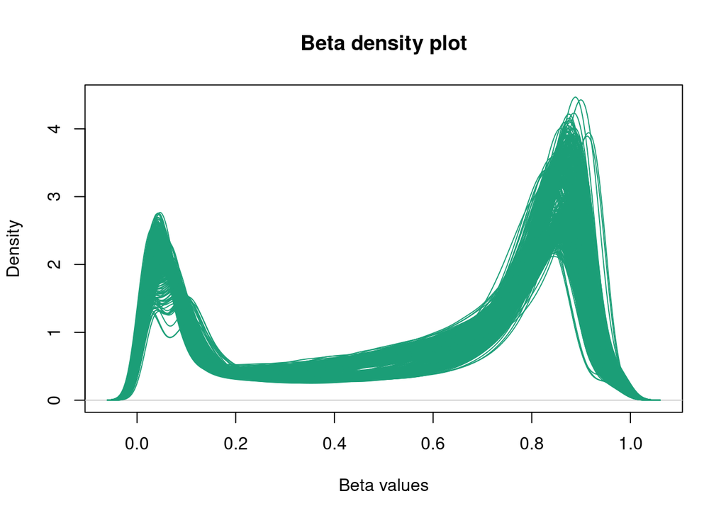

```r
densityPlot(
  RGset,
  main="Beta density plot",
  xlab="Beta values")
```

# PCA

Calculate PCs

```r
pc <- prcomp_irlba(
  t(betas),
  n=6)

summary(pc)
```

```
## Importance of components:
##                           PC1     PC2      PC3     PC4    PC5     PC6
## Standard deviation     66.284 33.4194 14.31651 13.6111 8.9570 7.65194
## Proportion of Variance  0.619  0.1573  0.02888  0.0261 0.0113 0.00825
## Cumulative Proportion   0.619  0.7763  0.80519  0.8313 0.8426 0.85085
```

Add PCs to targets

```r
targets <- cbind(
  targets,
  pc$x)
```

The PCA analysis can result in two different symmetrical clusters. This code handles those two eventualities and saves IDs to remove.

```r
if(nrow(targets %>%
        dplyr::filter(PC1 < -30 & tissue != "fasted blood")) == 2) {
  pc_blood <- "right"
} else {
  pc_blood <- "left"
}
```

Plot the first two PCs against each other to ensure the primary source of variability is tissue.

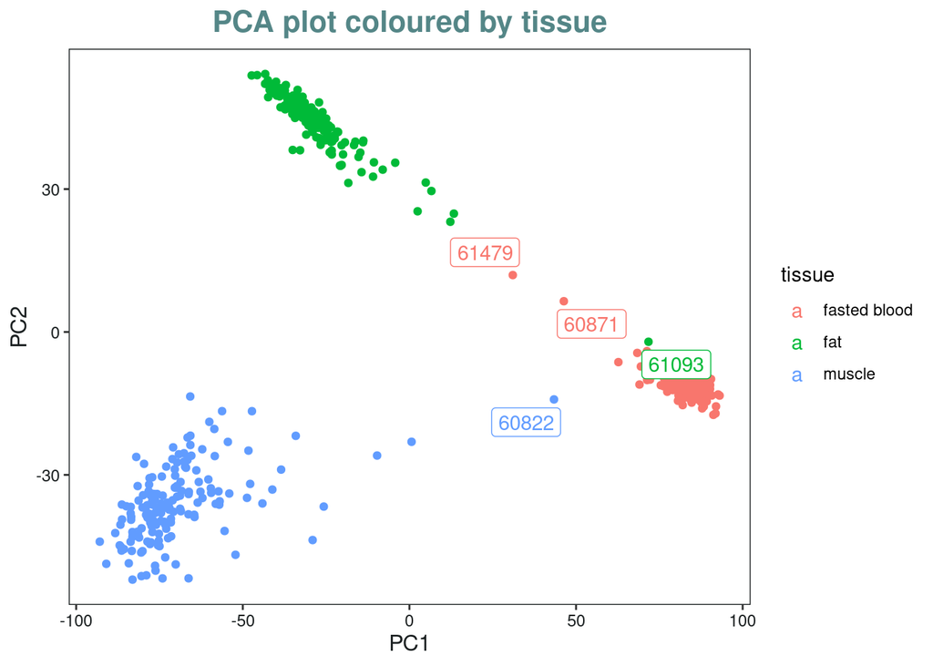

```r
if(pc_blood == "right"){
  pca_plot <- targets %>%
  ggplot(aes(
    x=PC1,
    y=PC2,
    label = ifelse(
        (PC1 < -30 & tissue != "fasted blood") |
        (PC1 > -60 & tissue == "fasted blood"),
        as.character(IOP2_ID), NA)
  ))
} else {
  pca_plot <- targets %>%
  ggplot(aes(
    x=PC1,
    y=PC2,
    label = ifelse(
        (PC1 > 30 & tissue != "fasted blood") |
        (PC1 < 60 & tissue == "fasted blood"),
        as.character(IOP2_ID), NA)
  ))
}

pca_plot +
  geom_point(
    aes(
      colour = tissue)) +
  geom_label_repel(
    aes(color = tissue),
    fill = "white"
  ) +
  xlab("PC1") +
  ylab("PC2") +
  ggtitle("PCA plot coloured by tissue") +
  theme(
    axis.text = element_text(
       size=9,
       color="#1B2021"),
    axis.title = element_text(
      size=12,
      hjust=0.5,
      color="#1B2021"),
    plot.title = element_text(
      size=16,
      hjust=0.5,
      face="bold",
      color = "#548687"),
    panel.background = element_rect(
      fill="white", color="#1B2021"),
    panel.grid.major = element_blank(),
    panel.grid.minor = element_blank(),
    plot.background = element_rect(
      fill="white"))
```

There are a few outliers than should be removed:

- One fat sample and its pair, which clusters closely to the blood samples. It is likely this was a very bloody biopsy.
- One muscle sample and its pair, which similarly clusters close to the blood samples
- Two blood samples and their pairs, which cluster close to the fat samples. Potentially, these individual had higher levels of lipids in their blood.

Save the outliers

```r
outliers <- targets %>%
  dplyr::filter(
      (IOP2_ID == "61479" & tissue == "fasted blood") |
      (IOP2_ID == "60871" & tissue == "fasted blood") |
      (IOP2_ID == "61093" & tissue == "fat") |
      (IOP2_ID == "60822" & tissue == "muscle"))
```

Remove them from targets

```r
targets <- targets[!(targets$Basename %in% outliers$Basename),]

print(paste0("Data on ", nrow(targets), " samples remains..."))
```

```
## [1] "Data on 548 samples remains..."
```

# Add smoking

Import data

```r
smoke_df <- read_csv('../Pheno/GOTO_SmokingData_20201117_v2.csv')
```

Create smoking var and inspect

```r
smoke_df <- smoke_df %>%
  mutate(smoke = case_when(
    (CurrentSmoking == 1) ~ 2,
    (CurrentSmoking == 0) & (EverSmoked == 1) ~ 1,
    (CurrentSmoking == 0) & (EverSmoked == 0) ~ 0
  ))
xtabs(~smoke_df$smoke + smoke_df$CurrentSmoking)
```

```
##               smoke_df$CurrentSmoking
## smoke_df$smoke  0  1
##              0 52  0
##              1 99  0
##              2  0 12
```

```r
xtabs(~smoke_df$smoke + smoke_df$EverSmoked)
```

```
##               smoke_df$EverSmoked
## smoke_df$smoke  0  1
##              0 52  0
##              1  0 99
##              2  0 12
```

Remove original vars

```r
smoke_df <- smoke_df %>% dplyr::select(IOP2_ID, smoke) %>% mutate(IOP2_ID = as.factor(IOP2_ID))
```

Add to targets

```r
targets <- left_join(targets, smoke_df, by='IOP2_ID')
xtabs(~targets$smoke)
```

```
## targets$smoke
##   0   1   2
## 186 336  26
```

# Save Unfiltered Data

Attach `targets` rownames and remove PCs

```r
rownames(targets) <- targets$Basename
targets <- targets %>%
  dplyr::select(-PC1, -PC2, -PC3, -PC4, -PC5, -PC6)
```

Subset `betas` to include only target samples and check order

```r
betas <- betas[,colnames(betas) %in% rownames(targets)]

xtabs(~colnames(betas) == rownames(targets))
```

```
## colnames(betas) == rownames(targets)
## TRUE
##  548
```

Subset annotation to include only probes in `betas`

```r
anno <- anno %>% filter(cpg %in% rownames(betas))
str(anno)
```

```
## tibble [865,859 × 7] (S3: tbl_df/tbl/data.frame)
##  $ cpg         : chr [1:865859] "cg14817997" "cg26928153" "cg16269199" "cg13869341" ...
##  $ chr         : chr [1:865859] "1" "1" "1" "1" ...
##  $ start       : num [1:865859] 10524 10847 10849 15864 18826 ...
##  $ end         : num [1:865859] 10526 10849 10851 15866 18828 ...
##  $ strand      : chr [1:865859] "-" "+" "+" "-" ...
##  $ gene_HGNC   : chr [1:865859] NA "DDX11L1" "DDX11L1" "WASH7P" ...
##  $ MASK_general: logi [1:865859] TRUE TRUE TRUE TRUE TRUE TRUE ...
```

```r
betas <- betas[rownames(betas) %in% anno$cpg,]
```

Save unfiltered values as a `SummarizedExperiment` object before probe removal

```r
methData_unfiltered <- SummarizedExperiment(
  assays=SimpleList(beta=betas),
  colData=targets,
  rowData=anno)

methData_unfiltered
```

```
## class: SummarizedExperiment
## dim: 865859 548
## metadata(0):
## assays(1): beta
## rownames(865859): cg18478105 cg09835024 ... cg10633746 cg12623625
## rowData names(7): cpg chr ... gene_HGNC MASK_general
## colnames(548): 203527980082_R01C01 203527980082_R02C01 ...
##   203550300093_R07C01 203550300093_R08C01
## colData names(19): DNA_labnr IOP2_ID ... Basename smoke
```

```r
save(
  methData_unfiltered,
  file="../Processing/GOTO_methData-unfiltered.Rdata")

save(
  targets,
  file="../Processing/GOTO_targets-unfiltered.Rdata")
```

Subset `RGset` and check column order

```r
RGset <- RGset[,colnames(RGset) %in% rownames(targets)]
RGset
```

```
## class: RGChannelSetExtended
## dim: 1051815 548
## metadata(0):
## assays(5): Green Red GreenSD RedSD NBeads
## rownames(1051815): 1600101 1600111 ... 99810990 99810992
## rowData names(0):
## colnames(548): 203527980082_R01C01 203527980082_R02C01 ...
##   203550300093_R07C01 203550300093_R08C01
## colData names(19): DNA_labnr IOP2_ID ... Basename filenames
## Annotation
##   array: IlluminaHumanMethylationEPIC
##   annotation: ilm10b4.hg19
```

```r
xtabs(~colnames(RGset) == rownames(targets))
```

```
## colnames(RGset) == rownames(targets)
## TRUE
##  548
```

Save RGset

```r
RGset <- RGset[ , colnames(RGset) %in% colnames(betas)]

save(
  RGset,
  file = "../Processing/GOTO_RGset-unfiltered.Rdata")
```

Clear

```r
rm(list=ls())
```